# HW5 -- Artificial Artificial Intelligence

```python
import pandas as pd
import numpy as np

neg = pd.read_csv('AMT_neg.csv')
pos = pd.read_csv('AMT_pos.csv')
```

## Initial EDA

```python
neg[:3]
```

|  | HITId | HITTypeId | Title | Description | Keywords | Reward | CreationTime | MaxAssignments | RequesterAnnotation | AssignmentDurationInSeconds | ... | RejectionTime | RequesterFeedback | WorkTimeInSeconds | LifetimeApprovalRate | Last30DaysApprovalRate | Last7DaysApprovalRate | Input.text | Answer.sentiment.label | Approve | Reject |
| --- | --- | --- | --- | --- | --- | --- | --- | --- | --- | --- | --- | --- | --- | --- | --- | --- | --- | --- | --- | --- | --- |
| 0 | 3IQ9O0AYW6ZI3GD740H32KGG2SWITJ | 3N0K7CX2I27L2NR2L8D93MF8LIRA5J | Sentiment analysis | Sentiment analysis | sentiment, text | $0.02 | Fri Nov 01 12:08:17 PDT 2019 | 3 | BatchId:3821423;OriginalHitTemplateId:928390909; | 10800 | ... | NaN | NaN | 44 | 0% (0/0) | 0% (0/0) | 0% (0/0) | Missed Opportunity\nI had been very excited to... | Neutral | NaN | NaN |
| 1 | 3IQ9O0AYW6ZI3GD740H32KGG2SWITJ | 3N0K7CX2I27L2NR2L8D93MF8LIRA5J | Sentiment analysis | Sentiment analysis | sentiment, text | $0.02 | Fri Nov 01 12:08:17 PDT 2019 | 3 | BatchId:3821423;OriginalHitTemplateId:928390909; | 10800 | ... | NaN | NaN | 7 | 0% (0/0) | 0% (0/0) | 0% (0/0) | Missed Opportunity\nI had been very excited to... | Negative | NaN | NaN |
| 2 | 3IQ9O0AYW6ZI3GD740H32KGG2SWITJ | 3N0K7CX2I27L2NR2L8D93MF8LIRA5J | Sentiment analysis | Sentiment analysis | sentiment, text | $0.02 | Fri Nov 01 12:08:17 PDT 2019 | 3 | BatchId:3821423;OriginalHitTemplateId:928390909; | 10800 | ... | NaN | NaN | 449 | 0% (0/0) | 0% (0/0) | 0% (0/0) | Missed Opportunity\nI had been very excited to... | Positive | NaN | NaN |

3 rows × 31 columns

```python
pos[:3]
```

|  | HITId | HITTypeId | Title | Description | Keywords | Reward | CreationTime | MaxAssignments | RequesterAnnotation | AssignmentDurationInSeconds | ... | RejectionTime | RequesterFeedback | WorkTimeInSeconds | LifetimeApprovalRate | Last30DaysApprovalRate | Last7DaysApprovalRate | Input.text | Answer.sentiment.label | Approve | Reject |
| --- | --- | --- | --- | --- | --- | --- | --- | --- | --- | --- | --- | --- | --- | --- | --- | --- | --- | --- | --- | --- | --- |
| 0 | 3VMV5CHJZ8F47P7CECH0H830NF4GTP | 3N0K7CX2I27L2NR2L8D93MF8LIRA5J | Sentiment analysis | Sentiment analysis | sentiment, text | $0.02 | Fri Nov 01 12:11:19 PDT 2019 | 3 | BatchId:3821427;OriginalHitTemplateId:928390909; | 10800 | ... | NaN | NaN | 355 | 0% (0/0) | 0% (0/0) | 0% (0/0) | funny like a clown\nGreetings again from the d... | Positive | NaN | NaN |
| 1 | 3VMV5CHJZ8F47P7CECH0H830NF4GTP | 3N0K7CX2I27L2NR2L8D93MF8LIRA5J | Sentiment analysis | Sentiment analysis | sentiment, text | $0.02 | Fri Nov 01 12:11:19 PDT 2019 | 3 | BatchId:3821427;OriginalHitTemplateId:928390909; | 10800 | ... | NaN | NaN | 487 | 0% (0/0) | 0% (0/0) | 0% (0/0) | funny like a clown\nGreetings again from the d... | Neutral | NaN | NaN |
| 2 | 3VMV5CHJZ8F47P7CECH0H830NF4GTP | 3N0K7CX2I27L2NR2L8D93MF8LIRA5J | Sentiment analysis | Sentiment analysis | sentiment, text | $0.02 | Fri Nov 01 12:11:19 PDT 2019 | 3 | BatchId:3821427;OriginalHitTemplateId:928390909; | 10800 | ... | NaN | NaN | 1052 | 0% (0/0) | 0% (0/0) | 0% (0/0) | funny like a clown\nGreetings again from the d... | Positive | NaN | NaN |

3 rows × 31 columns

```python
neg.columns.tolist()
```

```
['HITId',
 'HITTypeId',
 'Title',
 'Description',
 'Keywords',
 'Reward',
 'CreationTime',
 'MaxAssignments',
 'RequesterAnnotation',
 'AssignmentDurationInSeconds',
 'AutoApprovalDelayInSeconds',
 'Expiration',
 'NumberOfSimilarHITs',
 'LifetimeInSeconds',
 'AssignmentId',
 'WorkerId',
 'AssignmentStatus',
 'AcceptTime',
 'SubmitTime',
 'AutoApprovalTime',
 'ApprovalTime',
 'RejectionTime',
 'RequesterFeedback',
 'WorkTimeInSeconds',
 'LifetimeApprovalRate',
 'Last30DaysApprovalRate',
 'Last7DaysApprovalRate',
 'Input.text',
 'Answer.sentiment.label',
 'Approve',
 'Reject']
```

### How many unique turkers worked on each dataframe?

```python
def get_unique(df, column):
    unique = np.unique(df[column], return_counts=True)
    df = pd.DataFrame(zip(unique[0], unique[1]))
    return len(unique[0]), unique, df

num_neg, unique_neg, u_neg_df = get_unique(neg, 'WorkerId')
num_pos, unique_pos, u_pos_df = get_unique(pos, 'WorkerId')

print(num_neg, 'Turkers worked on NEG batch')
print(num_pos, 'Turkers worked on POS batch')
```

```
53 Turkers worked on NEG batch
38 Turkers worked on POS batch
```

### How many HITS did each unique turker do?

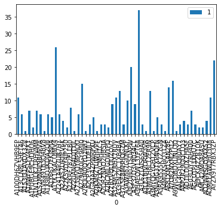

```python
u_neg_df.plot(kind='bar',x=0,y=1)
```

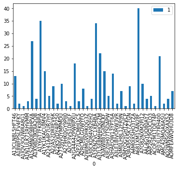

```python
u_pos_df.plot(kind='bar',x=0,y=1)
```

### What's the `max` and `min` HIT for unique turkers

```python
print('For {}, the min was: {} and the max was: {}'.format('neg', unique_neg[1].min(), unique_neg[1].max()))
print('For {}, the min was: {} and the max was: {}'.format('pos', unique_pos[1].min(), unique_pos[1].max()))
```

```
For neg, the min was: 1 and the max was: 37
For pos, the min was: 1 and the max was: 40
```

### Did a specitic Sentiment take longer for turkers to assess?

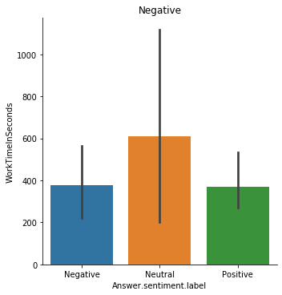

```python
import seaborn as sns
import matplotlib.pyplot as plt
sns.catplot(x="Answer.sentiment.label",
            y="WorkTimeInSeconds",
            kind="bar",
            order=['Negative', 'Neutral', 'Positive'],
            data=neg);
plt.title('Negative')
```

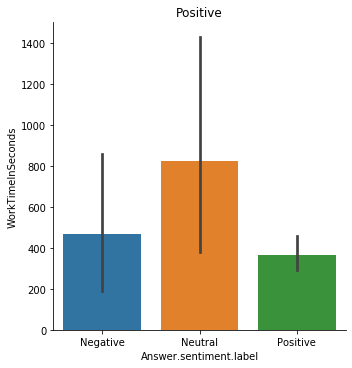

```python
sns.catplot(x="Answer.sentiment.label",
            y="WorkTimeInSeconds",
            kind="bar",
            order=['Negative', 'Neutral', 'Positive'],
            data=pos)
plt.title('Positive')
```

### How many turkers had less than 10 second response time?

```python
response_time = neg[neg['WorkTimeInSeconds'] < 10]
response_time_check = neg[neg['WorkTimeInSeconds'] > 10]
```

```python
len(response_time)
```

```
48
```

```python
len(response_time_check)
```

```
312
```

### Checking for potential bots

#### Did anyone have a consistent average low response time?

```python
count = pos.groupby(['WorkerId'])['HITId'].count()
work_time = pos.groupby(['WorkerId'])['WorkTimeInSeconds'].mean()
new_df = pd.DataFrame([work_time, count]).T
new_df[:5]
```

| WorkerId | WorkTimeInSeconds | HITId |
| --- | --- | --- |
| A13CLN8L5HFT46 | 7.230769 | 13.0 |
| A18WFPSLFV4FKY | 47.000000 | 2.0 |
| A1IQV3QUWRA8G1 | 22.000000 | 1.0 |
| A1N1ULK71RHVMM | 10.000000 | 3.0 |
| A1S2MN0E9BHPVA | 173.444444 | 27.0 |

#### Did anyone have a consistent average high response time?

```python
new_df['WorkTimeInMin'] = new_df['WorkTimeInSeconds']/60
new_df[:5]
```

| WorkerId | WorkTimeInSeconds | HITId | WorkTimeInMin |
| --- | --- | --- | --- |
| A13CLN8L5HFT46 | 7.230769 | 13.0 | 0.120513 |
| A18WFPSLFV4FKY | 47.000000 | 2.0 | 0.783333 |
| A1IQV3QUWRA8G1 | 22.000000 | 1.0 | 0.366667 |
| A1N1ULK71RHVMM | 10.000000 | 3.0 | 0.166667 |
| A1S2MN0E9BHPVA | 173.444444 | 27.0 | 2.890741 |

```python
count = pos.groupby(['WorkerId', 'Answer.sentiment.label'])['Answer.sentiment.label'].count()
# count = pos.groupby(['WorkerId'])['Answer.sentiment.label'].count()
count
```

```
WorkerId        Answer.sentiment.label
A13CLN8L5HFT46  Neutral                    2
                Positive                  11
A18WFPSLFV4FKY  Positive                   2
A1IQV3QUWRA8G1  Positive                   1
A1N1ULK71RHVMM  Negative                   1
                                          ..
AMC42JMQA8A5U   Positive                   1
AO2WNSGOXAX52   Neutral                    3
                Positive                   1
AOMFEAWQHU3D8   Neutral                    1
                Positive                   6
Name: Answer.sentiment.label, Length: 74, dtype: int64
```

#### Did anyone answer ONLY pos/neg/neutral?

```python
pnn = pd.DataFrame()
pnn['Neutral'] = pos.groupby('WorkerId')['Answer.sentiment.label'].apply(lambda x: (x=='Neutral').sum())
pnn['Positive'] = pos.groupby('WorkerId')['Answer.sentiment.label'].apply(lambda x: (x=='Positive').sum())
pnn['Negative'] = pos.groupby('WorkerId')['Answer.sentiment.label'].apply(lambda x: (x=='Negative').sum())
pnn['Total'] = pos.groupby('WorkerId')['Answer.sentiment.label'].apply(lambda x: x.count())
pnn[:5]
```

| WorkerId | Neutral | Positive | Negative | Total |
| --- | --- | --- | --- | --- |
| A13CLN8L5HFT46 | 2 | 11 | 0 | 13 |
| A18WFPSLFV4FKY | 0 | 2 | 0 | 2 |
| A1IQV3QUWRA8G1 | 0 | 1 | 0 | 1 |
| A1N1ULK71RHVMM | 0 | 2 | 1 | 3 |
| A1S2MN0E9BHPVA | 2 | 21 | 4 | 27 |

#### This is getting a little confusing, let's just look at our top performers

```python
top = pnn.sort_values(by=['Total'], ascending=False)
```

```python
top[:10]
```

| WorkerId | Neutral | Positive | Negative | Total |
| --- | --- | --- | --- | --- |
| A681XM15AN28F | 13 | 20 | 7 | 40 |
| A1Y66T7FKJ8PJA | 5 | 23 | 7 | 35 |
| A33ENZVC1XB4BA | 0 | 34 | 0 | 34 |
| A1S2MN0E9BHPVA | 2 | 21 | 4 | 27 |
| A37L5E8MHHQGZM | 6 | 13 | 3 | 22 |
| AE03LUY7RH400 | 4 | 10 | 7 | 21 |
| A2G44A4ZPWRPXU | 4 | 12 | 2 | 18 |
| A1YK1IKACUJMV4 | 0 | 15 | 0 | 15 |
| A3AW887GI0NLKF | 3 | 10 | 2 | 15 |
| A3HAEQW13YPT6A | 0 | 14 | 0 | 14 |

Interesting!! Looking from here, we have three workers who ONLY chose positive.

Let's look at their response time to see if we can determine if they are a bot!!

```python
top['Avg_WorkTimeInSeconds'] = pos.groupby('WorkerId')['WorkTimeInSeconds'].apply(lambda x: x.mean())
top['Avg_WorkTimeInMin'] = pos.groupby('WorkerId')['WorkTimeInSeconds'].apply(lambda x: x.mean()/60)
top['Min_WorkTimeInMin'] = pos.groupby('WorkerId')['WorkTimeInSeconds'].apply(lambda x: x.min()/60)
top['Max_WorkTimeInMin'] = pos.groupby('WorkerId')['WorkTimeInSeconds'].apply(lambda x: x.max()/60)
```

```python
top[:10]
```

| WorkerId | Neutral | Positive | Negative | Total | Avg_WorkTimeInSeconds | Avg_WorkTimeInMin | Min_WorkTimeInMin | Max_WorkTimeInMin |
| --- | --- | --- | --- | --- | --- | --- | --- | --- |
| A681XM15AN28F | 13 | 20 | 7 | 40 | 13.575000 | 0.226250 | 0.100000 | 0.833333 |
| A1Y66T7FKJ8PJA | 5 | 23 | 7 | 35 | 695.857143 | 11.597619 | 0.216667 | 22.000000 |
| A33ENZVC1XB4BA | 0 | 34 | 0 | 34 | 366.647059 | 6.110784 | 0.616667 | 9.916667 |
| A1S2MN0E9BHPVA | 2 | 21 | 4 | 27 | 173.444444 | 2.890741 | 0.400000 | 4.983333 |
| A37L5E8MHHQGZM | 6 | 13 | 3 | 22 | 346.272727 | 5.771212 | 2.150000 | 8.283333 |
| AE03LUY7RH400 | 4 | 10 | 7 | 21 | 102.238095 | 1.703968 | 0.100000 | 3.433333 |
| A2G44A4ZPWRPXU | 4 | 12 | 2 | 18 | 221.277778 | 3.687963 | 0.383333 | 7.383333 |
| A1YK1IKACUJMV4 | 0 | 15 | 0 | 15 | 593.600000 | 9.893333 | 1.716667 | 11.000000 |
| A3AW887GI0NLKF | 3 | 10 | 2 | 15 | 269.400000 | 4.490000 | 1.616667 | 7.216667 |
| A3HAEQW13YPT6A | 0 | 14 | 0 | 14 | 442.928571 | 7.382143 | 0.866667 | 11.100000 |

HOWEVER, worker `A681XM15AN28F` appears to only work for an average of 13 seconds per review which doesn't seem like enough time to read and judge a review...

## PART 2: Second submission to AMT

TOO MANY REVIEWERS!

Here is when we realized that doing a kappa score with over 30 individual reviewers would be tricky, so we rusubmitted to AMT and required the turkers to be 'Master' in the hopes that this additional barrier-to-entry would help reduce the amount of turkers working on the project

```python
v2 = pd.read_csv('HW5_amt_v2.csv')
v2[:5]
len(v2)
```

```
293
```

This time, I didn't separate the df into pos and neg before submitting to AMT, so we have to reimport the labels.

```python
labels = pd.read_csv('all_JK_extremes_labeled.csv')
```

```python
len(labels)
```

```
98
```

Oops! That's right, we replicated each review * 3 so three separate people could look at each review

```python
labels2 = labels.append([labels] * 2, ignore_index=True)
```

```python
len(labels2)
```

```
294
```

```python
labels2.sort_values(by='0')
```

|  | 0 | PoN |
| --- | --- | --- |
| 76 | #LetRottenTomatoesRotSquad\nI am a simple guy... | P |
| 174 | #LetRottenTomatoesRotSquad\nI am a simple guy... | P |
| 272 | #LetRottenTomatoesRotSquad\nI am a simple guy... | P |
| 116 | A 'Triumph of the Will' for Nihilists\n'Joker... | N |
| 18 | A 'Triumph of the Will' for Nihilists\n'Joker... | N |
| ... | ... | ... |
| 227 | lose of both time and money\nThis was one of ... | N |
| 31 | lose of both time and money\nThis was one of ... | N |
| 207 | poor plot\nPoor plot. i find no reason for jo... | N |
| 11 | poor plot\nPoor plot. i find no reason for jo... | N |
| 109 | poor plot\nPoor plot. i find no reason for jo... | N |

294 rows × 2 columns

Shoot! I realized I had to delete some emojis for the csv to be accepted by AMT, so the reviews themselves won't actually be matching... solution: Create two 'for-matching' columns made up of the first 5 words of each review

```python
v2['for_matching'] = v2.apply(lambda x: x['Input.text'].split()[:5], axis=1)
```

```python
labels2['for_matching'] = labels2.apply(lambda x: x['0'].split()[:5], axis=1)
```

Annnnnd why did I do that when I could just sort the df and apply the PoN

```python
sorted_labels = labels2.sort_values(by='0')
sorted_labels[:6]
```

|  | 0 | PoN | for_matching |
| --- | --- | --- | --- |
| 76 | #LetRottenTomatoesRotSquad\nI am a simple guy... | P | [#LetRottenTomatoesRotSquad, I, am, a, simple] |
| 174 | #LetRottenTomatoesRotSquad\nI am a simple guy... | P | [#LetRottenTomatoesRotSquad, I, am, a, simple] |
| 272 | #LetRottenTomatoesRotSquad\nI am a simple guy... | P | [#LetRottenTomatoesRotSquad, I, am, a, simple] |
| 116 | A 'Triumph of the Will' for Nihilists\n'Joker... | N | [A, 'Triumph, of, the, Will'] |
| 18 | A 'Triumph of the Will' for Nihilists\n'Joker... | N | [A, 'Triumph, of, the, Will'] |
| 214 | A 'Triumph of the Will' for Nihilists\n'Joker... | N | [A, 'Triumph, of, the, Will'] |

```python
sorted_v2 = v2.sort_values(by='Input.text')
sorted_v2[sorted_v2.columns[-5:]][:6]
```

|  | Input.text | Answer.sentiment.label | Approve | Reject | for_matching |
| --- | --- | --- | --- | --- | --- |
| 229 | #LetRottenTomatoesRotSquad\nI am a simple guy... | Positive | NaN | NaN | [#LetRottenTomatoesRotSquad, I, am, a, simple] |
| 228 | #LetRottenTomatoesRotSquad\nI am a simple guy... | Positive | NaN | NaN | [#LetRottenTomatoesRotSquad, I, am, a, simple] |
| 227 | #LetRottenTomatoesRotSquad\nI am a simple guy... | Positive | NaN | NaN | [#LetRottenTomatoesRotSquad, I, am, a, simple] |
| 53 | A 'Triumph of the Will' for Nihilists\n'Joker... | Neutral | NaN | NaN | [A, 'Triumph, of, the, Will'] |
| 55 | A 'Triumph of the Will' for Nihilists\n'Joker... | Negative | NaN | NaN | [A, 'Triumph, of, the, Will'] |
| 54 | A 'Triumph of the Will' for Nihilists\n'Joker... | Negative | NaN | NaN | [A, 'Triumph, of, the, Will'] |

```python
all_df = sorted_v2.copy()
# all_df['PoN'] = sorted_labels['PoN'].tolist()
# THIS DIDN'T WORK BECAUSE I DIDN'T WAIT UNTIL ALL WERE DONE FROM AMT. RESEARCHER ERROR BUT OMG I HATE MYSELF
```

```python
len(all_df)
```

```
293
```

```python
293/3
```

```
97.66666666666667
```

Confirming that YEP. 293 isn't divisible by 3, meaning I didn't wait until the last turker finished. omg.

#### Reuploading now -- WITH BETTER CODE AND BETTER VARIABLE NAMES!

```python
turker = pd.read_csv('HW5_amt_294.csv')
print(len(turker))
turker[turker.columns[-5:]][:5]
```

```
294
```

|  | Last7DaysApprovalRate | Input.text | Answer.sentiment.label | Approve | Reject |
| --- | --- | --- | --- | --- | --- |
| 0 | 0% (0/0) | Everyone praised an overrated movie.\nOverrat... | Negative | NaN | NaN |
| 1 | 0% (0/0) | Everyone praised an overrated movie.\nOverrat... | Negative | NaN | NaN |
| 2 | 0% (0/0) | Everyone praised an overrated movie.\nOverrat... | Negative | NaN | NaN |
| 3 | 0% (0/0) | What idiotic FIlm\nI can say that Phoenix is ... | Negative | NaN | NaN |
| 4 | 0% (0/0) | What idiotic FIlm\nI can say that Phoenix is ... | Negative | NaN | NaN |

```python
# Getting labels...
labels = pd.read_csv('all_JK_extremes_labeled.csv')
# X3
labels = labels.append([labels] * 2, ignore_index=True)
print(len(labels))
labels[:5]
```

```
294
```

|  | 0 | PoN |
| --- | --- | --- |
| 0 | Everyone praised an overrated movie.\nOverrat... | N |
| 1 | What idiotic FIlm\nI can say that Phoenix is ... | N |
| 2 | Terrible\nThe only thing good about this movi... | N |
| 3 | Watch Taxi Driver instead\nThis is a poor att... | N |
| 4 | I learned one thing.\nIt borrows a lot of ele... | N |

#### NOW, TO SORT!

```python
sorted_labels = labels.sort_values(by=['0'])
sorted_turker = turker.sort_values(by=['Input.text'])
```

```python
sorted_labels[:5]
```

|  | 0 | PoN |
| --- | --- | --- |
| 76 | #LetRottenTomatoesRotSquad\nI am a simple guy... | P |
| 174 | #LetRottenTomatoesRotSquad\nI am a simple guy... | P |
| 272 | #LetRottenTomatoesRotSquad\nI am a simple guy... | P |
| 116 | A 'Triumph of the Will' for Nihilists\n'Joker... | N |
| 18 | A 'Triumph of the Will' for Nihilists\n'Joker... | N |

```python
sorted_turker['Input.text'][:5]
```

```
228     #LetRottenTomatoesRotSquad\nI am a simple guy...
229     #LetRottenTomatoesRotSquad\nI am a simple guy...
230     #LetRottenTomatoesRotSquad\nI am a simple guy...
56      A 'Triumph of the Will' for Nihilists\n'Joker...
55      A 'Triumph of the Will' for Nihilists\n'Joker...
Name: Input.text, dtype: object
```

OMG HOORAY HOORAY HOORAY!!

NOTE: FUN FACT!! I can type here and then hit the `esc` key to turn this cell into markdown!!

```python
# YUCK THIS IS SO AGGRIVATING!! This line below doens't work because it still uses indexes.
# So the P and N didn't match up
# sorted_turker['PoN'] = sorted_labels['PoN']
sorted_turker['PoN'] = sorted_labels['PoN'].tolist()
sorted_turker[sorted_turker.columns[-5:]][:5]
```

|  | Input.text | Answer.sentiment.label | Approve | Reject | PoN |
| --- | --- | --- | --- | --- | --- |
| 228 | #LetRottenTomatoesRotSquad\nI am a simple guy... | Positive | NaN | NaN | P |
| 229 | #LetRottenTomatoesRotSquad\nI am a simple guy... | Positive | NaN | NaN | P |
| 230 | #LetRottenTomatoesRotSquad\nI am a simple guy... | Positive | NaN | NaN | P |
| 56 | A 'Triumph of the Will' for Nihilists\n'Joker... | Negative | NaN | NaN | N |
| 55 | A 'Triumph of the Will' for Nihilists\n'Joker... | Negative | NaN | NaN | N |

## PART 3: ANALYZE

First, let's clean ALL the things

```python
all_df = sorted_turker[['Input.text', 'WorkerId', 'Answer.sentiment.label', 'PoN']]
```

```python
all_df[:5]
```

|  | Input.text | WorkerId | Answer.sentiment.label | PoN |
| --- | --- | --- | --- | --- |
| 228 | #LetRottenTomatoesRotSquad\nI am a simple guy... | A681XM15AN28F | Positive | P |
| 229 | #LetRottenTomatoesRotSquad\nI am a simple guy... | A2XFO0X6RCS98M | Positive | P |
| 230 | #LetRottenTomatoesRotSquad\nI am a simple guy... | AURYD2FH3FUOQ | Positive | P |
| 56 | A 'Triumph of the Will' for Nihilists\n'Joker... | A1T79J0XQXDDGC | Negative | N |
| 55 | A 'Triumph of the Will' for Nihilists\n'Joker... | A2XFO0X6RCS98M | Negative | N |

```python
all_df_all = all_df.copy()
all_df_all['APoN'] = all_df_all.apply(lambda x: x['Answer.sentiment.label'][0], axis=1)
```

```python
all_df_all
```

|  | Input.text | WorkerId | Answer.sentiment.label | PoN | APoN |
| --- | --- | --- | --- | --- | --- |
| 228 | #LetRottenTomatoesRotSquad\nI am a simple guy... | A681XM15AN28F | Positive | P | P |
| 229 | #LetRottenTomatoesRotSquad\nI am a simple guy... | A2XFO0X6RCS98M | Positive | P | P |
| 230 | #LetRottenTomatoesRotSquad\nI am a simple guy... | AURYD2FH3FUOQ | Positive | P | P |
| 56 | A 'Triumph of the Will' for Nihilists\n'Joker... | A1T79J0XQXDDGC | Negative | N | N |
| 55 | A 'Triumph of the Will' for Nihilists\n'Joker... | A2XFO0X6RCS98M | Negative | N | N |
| ... | ... | ... | ... | ... | ... |
| 265 | Venice 76 review\nI have just watched the Joke... | ARLGZWN6W91WD | Positive | N | P |
| 266 | Venice 76 review\nI have just watched the Joke... | A38DC3BG1ZCVZ2 | Positive | N | P |
| 93 | lose of both time and money\nThis was one of t... | A2XFO0X6RCS98M | Negative | N | N |
| 94 | lose of both time and money\nThis was one of t... | A3EZ0H07TSDAPW | Negative | N | N |
| 95 | lose of both time and money\nThis was one of t... | ASB8T0H7L99RF | Negative | N | N |

294 rows × 5 columns

```python
all_df_all['agree'] = all_df_all.apply(lambda x: x['PoN'] == x['APoN'], axis=1)
```

```python
all_df_all[-10:]
```

|  | Input.text | WorkerId | Answer.sentiment.label | PoN | APoN | agree |
| --- | --- | --- | --- | --- | --- | --- |
| 38 | This is extremely bad...\nThis whole film make... | A3EZ0H07TSDAPW | Negative | N | N | True |
| 216 | Took my 65 year old mother to see it.\nI saw t... | A3EZ0H07TSDAPW | Positive | N | P | False |
| 217 | Took my 65 year old mother to see it.\nI saw t... | A2XFO0X6RCS98M | Positive | N | P | False |
| 218 | Took my 65 year old mother to see it.\nI saw t... | AKSJ3C5O3V9RB | Positive | N | P | False |
| 264 | Venice 76 review\nI have just watched the Joke... | A3EZ0H07TSDAPW | Positive | N | P | False |
| 265 | Venice 76 review\nI have just watched the Joke... | ARLGZWN6W91WD | Positive | N | P | False |
| 266 | Venice 76 review\nI have just watched the Joke... | A38DC3BG1ZCVZ2 | Positive | N | P | False |
| 93 | lose of both time and money\nThis was one of t... | A2XFO0X6RCS98M | Negative | N | N | True |
| 94 | lose of both time and money\nThis was one of t... | A3EZ0H07TSDAPW | Negative | N | N | True |
| 95 | lose of both time and money\nThis was one of t... | ASB8T0H7L99RF | Negative | N | N | True |

### Lets see how many agree!

```python
gdf = pd.DataFrame(all_df_all.groupby(['Input.text','PoN'])['agree'].mean())
gdf_forplot = gdf.copy()
gdf
```

| Input.text | PoN | agree |
| --- | --- | --- |
| #LetRottenTomatoesRotSquad\nI am a simple guy. I watch films, I enjoy life's simple pleasures.One thing I despise doing in life (because it feels pointless) is being far too judgemental or complex as … | P | 1.000000 |
| A 'Triumph of the Will' for Nihilists\n'Joker' is a sick, disgusting, dark, evil, violent, total piece of scheisse. It will seriously affect emotionally troubled young people already pulled at by suic… | N | 1.000000 |
| A Breath of Fresh Cinema\nBursting with emotion. This film has won me over and dug me out of a ditch of cheap CGI fan fare.Absolutely outstanding. Really well filmed. It's pace, tone and character imp… | P | 1.000000 |
| A MASTERPIECE\nJoaquin Phoenix's performance is different. He is over acting some times. Phoenix is not being true to the character. He is what he is because what he experienced. The childhood trauma … | N | 0.333333 |
| A brilliant movie\nThis movie is slow but never makes you feel bored. The story is narrated in a wonderful manner. This movie sets a good example for others comic based movies that how can a negative … | P | 1.000000 |
| ... | ... | ... |
| The mirror of society\nActing 10/10\nActors 10/10\nSound 8/10\nSoundtrack 9/10\nDolby Atmos 6/10\nDrama 9/10\nAction 3/10\nSuspense 9/10\nStory 10/10Conclusion:\nWhen you ever want to know why exist j… | N | 0.000000 |
| This is extremely bad...\nThis whole film makes no sense, it's, apperently, completely overhyped.\nI went to the theatre without any expectations, prejudice, etc. but man, what a bunch of...\nThis is … | N | 1.000000 |
| Took my 65 year old mother to see it.\nI saw the movie after the opening weekend and loved it. I think it's a masterpiece. Convinced my 65 year old mother too see it, who couldn't even remember whose … | N | 0.000000 |
| Venice 76 review\nI have just watched the Joker in Venice and I will say if Joaquin doesn't get an Oscar this year then something is wrong with this world. This perfomance is just jaw-dropping, it glu… | N | 0.000000 |
| lose of both time and money\nThis was one of the worse movies I have seen. It was over acted by all actors, the story dragged on and on. I saw this movie for a bargain matinee and thought I was ripped… | N | 1.000000 |

98 rows × 1 columns

OK so this actually gave us something we want... BUT PLEASE TELL ME THE BETTER WAY!!

```python
three_agreed = gdf[gdf['agree'] == 1]
len(three_agreed)
```

```
33
```

```python
three_agreed_but_wrong = gdf[gdf['agree'] == 0]
len(three_agreed_but_wrong)
```

```
31
```

```python
disparity = gdf[(gdf['agree'] > 0) & (gdf['agree'] < 1)]
len(disparity)
```

```
34
```

```python
quickdf = pd.DataFrame({'labels': ['agreed', 'agreed, incorrect', 'disparity'], 'counts': [33,31,34]})
quickdf
```

|  | labels | counts |
| --- | --- | --- |
| 0 | agreed | 33 |
| 1 | agreed, incorrect | 31 |
| 2 | disparity | 34 |

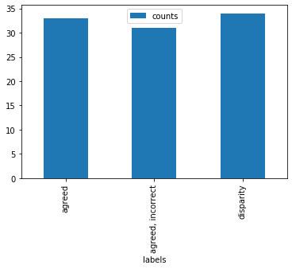

```python
quickdf.plot(kind='bar', x='labels', y='counts')
```

Lol that is not super useful

```python
# # three_agreed = gdf[(gdf['agree'] == 1) & (gdf['PoN'] == 'P')]
# # len(three_agreed)
# # gdf['PoN']
# gdf = gdf.reset_index()
# p_three_agreed = gdf[(gdf['agree'] == 1) & (gdf['PoN'] == 'P')]
# len(p_three_agreed)
```

```python
# gdf = gdf.reset_index(drop=True)
# n_three_agreed = gdf[(gdf['agree'] == 1) & (gdf['PoN'] == 'N')]
# len(n_three_agreed)
```

```python
# gdf = gdf.reset_index(drop=True)
# p_three_agreed_wrong = gdf[(gdf['agree'] == 0) & (gdf['PoN'] == 'P')]
# len(p_three_agreed_wrong)
```

```python
# gdf = gdf.reset_index(drop=True)
# n_three_agreed_wrong = gdf[(gdf['agree'] == 0) & (gdf['PoN'] == 'N')]
# len(n_three_agreed_wrong)
```

```python
# gdf = gdf.reset_index(drop=True)
# p_disparity = gdf[((gdf['agree'] / 1) != 0 ) & (gdf['PoN'] == 'P')]
# len(p_disparity)
```

```python
# gdf = gdf.reset_index(drop=True)
# n_disparity = gdf[(gdf['agree'] / 1 != 0 ) & (gdf['PoN'] == 'N')]
# len(n_disparity)
```

```python
# quickdf = pd.DataFrame({'labels': ['positive', 'negative'], 'counts': [18,15]})
# quickdf.plot(kind='bar', x='labels', y='counts')
```

```python
# sns.catplot(x="Answer.sentiment.label",
#             y="WorkTimeInSeconds",
#             kind="bar",
#             order=['Negative', 'Neutral', 'Positive'],
#             data=gdp_forplot);
# plt.title('By Polarity')
gdf_forplot = gdf_forplot.reset_index()
```

```python
gdf_forplot.groupby(['agree'])['agree'].count()
```

```
agree
0.000000    31
0.333333    17
0.666667    17
1.000000    33
Name: agree, dtype: int64
```

```python
gdf_forplot.groupby(['agree','PoN'])['agree'].count()
```

```
agree     PoN
0.000000  N      14
          P      17
0.333333  N      10
          P       7
0.666667  N       9
          P       8
1.000000  N      15
          P      18
Name: agree, dtype: int64
```